# R Ladies: warsztaty z pakietu ggplot2

Marta Sommer

20 października 2016

## Pakiety

Zainstaluj pakiet:

```r
install.packages("ggplot2")
```

Załaduj pakiety:

```r
library("ggplot2") # do rysowania wykresow
library("ggrepel") # ladniejsze geom_text()

library("PogromcyDanych") # dane znajduja sie w tym pakiecie

library("tidyr") # do zmieniania tabeli z postaci szerokiej w waska
library("dplyr") # do roznych (troche sql-owych) operacji na tabelach

library("plotly") # interaktywne wykresy
```

## Cheatsheet

https://www.rstudio.com/wp-content/uploads/2015/03/ggplot2-cheatsheet.pdf

## Dane

```r
data("koty_ptaki")
koty_ptaki
```

```
##           gatunek   waga dlugosc predkosc  habitat zywotnosc druzyna
## 1          Tygrys 300.00     2.5       60     Azja        25     Kot
## 2             Lew 200.00     2.0       80   Afryka        29     Kot
## 3          Jaguar 100.00     1.7       90  Ameryka        15     Kot
## 4            Puma  80.00     1.7       70  Ameryka        13     Kot
## 5         Leopard  70.00     1.4       85     Azja        21     Kot
## 6          Gepard  60.00     1.4      115   Afryka        12     Kot
## 7           Irbis  50.00     1.3       65     Azja        18     Kot
## 8          Jerzyk   0.05     0.2      170 Euroazja        20    Ptak
## 9           Strus 150.00     2.5       70   Afryka        45    Ptak
## 10  Orzel przedni   5.00     0.9      160   Polnoc        20    Ptak
## 11 Sokol wedrowny   0.70     0.5      110   Polnoc        15    Ptak
## 12 Sokol norweski   2.00     0.7      100   Polnoc        20    Ptak
## 13       Albatros   4.00     0.8      120 Poludnie        50    Ptak
```

## Struktura

```r
ggplot(ramka_z_danymi, aes(x = ?, y = ?, color = ?, fill = ?, label = ?,
                           shape = ?, size = ?)) +
     geom_point(...) +
     geom_bar(...) +
     geom_line(...) +
     geom_text(...) +
     ...
     coord_flip(...) +
     ...
     facet_grid(...) +
     ...
     theme_(bw/minimal/gray/...) +
     theme(axis.title = element_text(...),
           axis.text = element_text(...),
           legend.position = "top/bottom/...") +
     labs(title = "...", x = "...", y = "...") +
     ...
     scale_y_manual(values = ..., name = "...", label = ...) +
     scale_y_discrete() +
     scale_color_manual() +
     ...
```

## Geometrie i mapowania

Prosy wykres punktowy zależności długości od wagi:

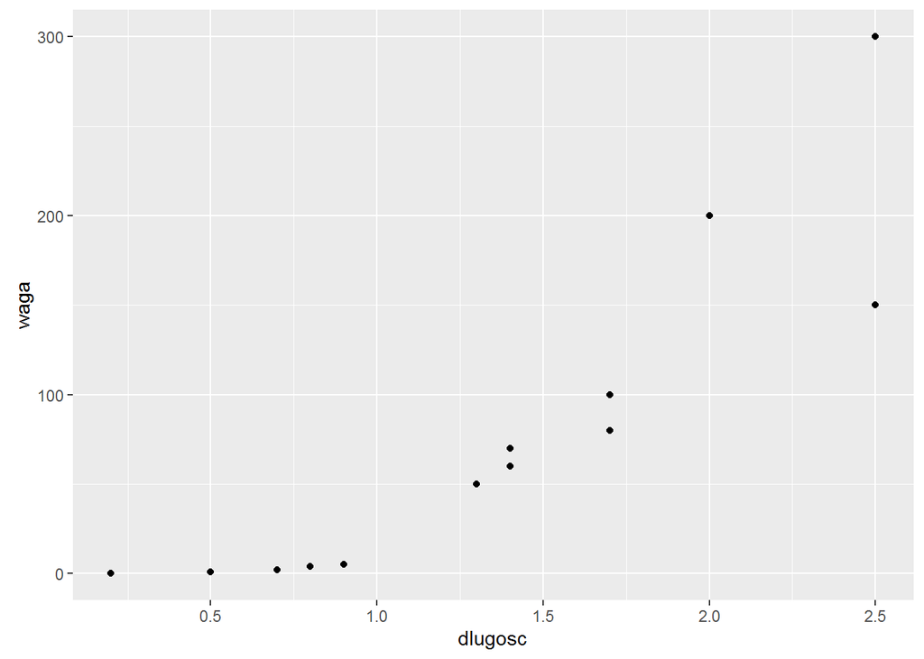

```r
ggplot(koty_ptaki, aes(x = dlugosc, y = waga)) +
     geom_point()
```

Dodajmy do wykresu jeszcze kolor określający drużynę:

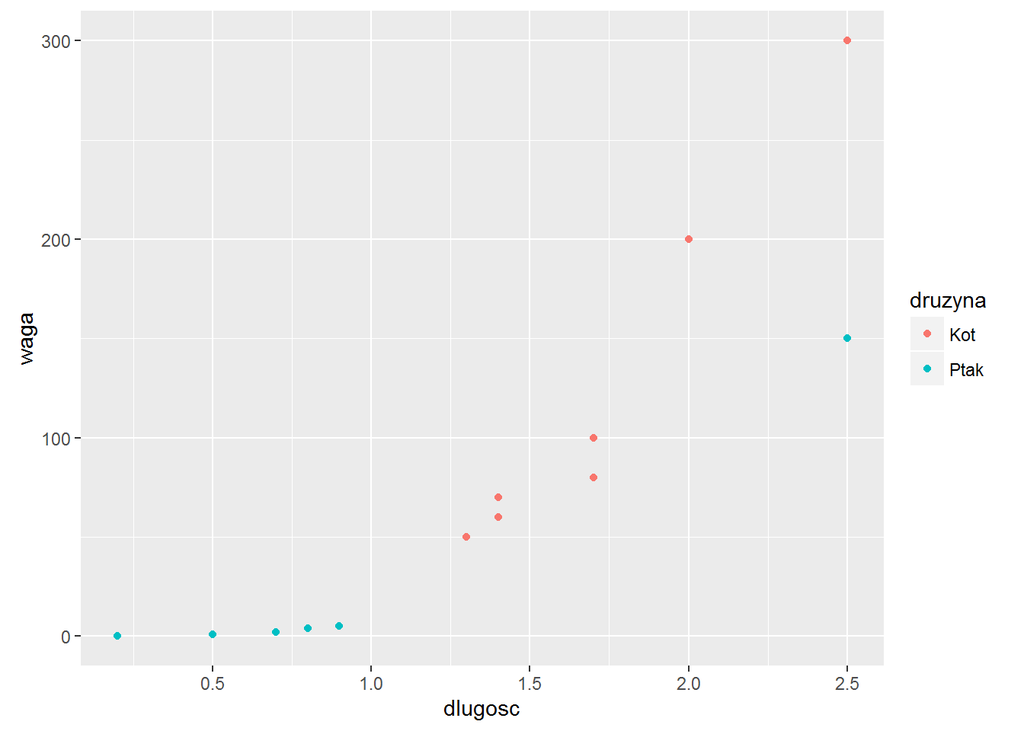

```r
ggplot(koty_ptaki, aes(x = dlugosc, y = waga, color = druzyna)) +
     geom_point()
```

Jedna obserwacja jest ewidentnie odstająca w grupie ptaków - dowiedzmy się jaka:

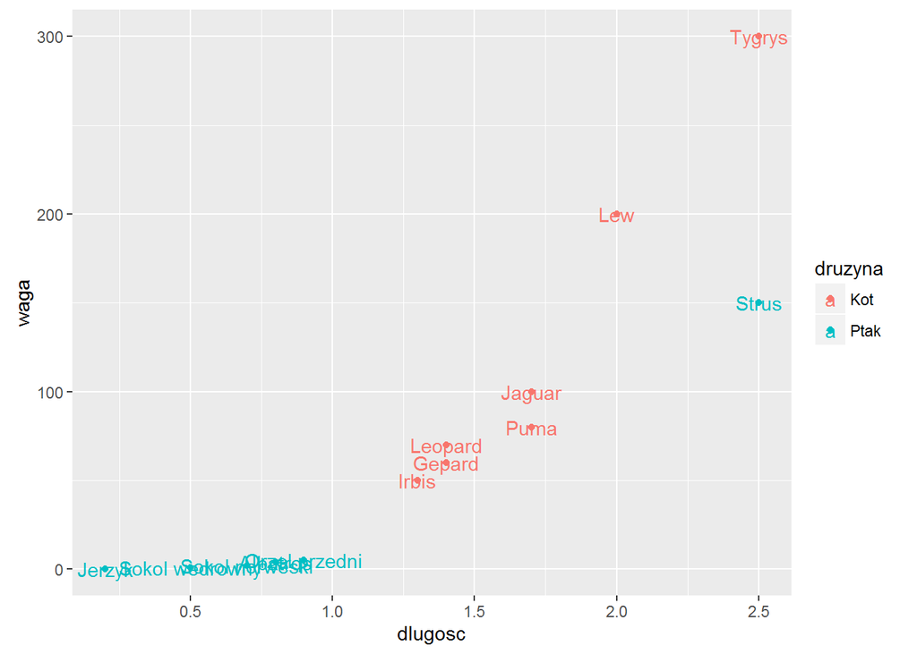

```r
ggplot(koty_ptaki, aes(x = dlugosc, y = waga, color = druzyna, label = gatunek)) +
     geom_point() +
     geom_text()
```

Punkty są za bliko siebie i napisy na siebie zachodzą. Ładnie radzi z tym sobie biblioteka `ggrepel` z funkcją `geom_text_repel()` zamiast `geom_text()`

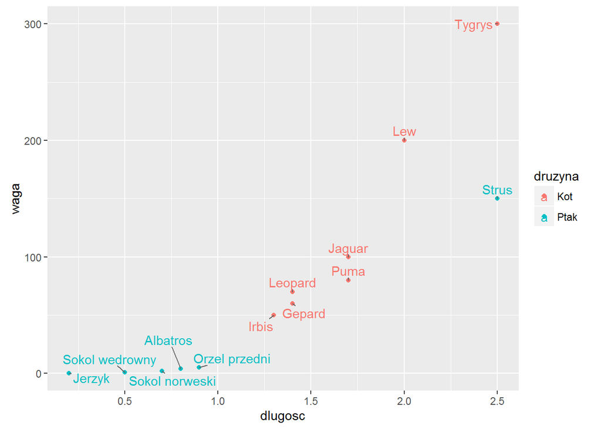

```r
ggplot(koty_ptaki, aes(x = dlugosc, y = waga, color = druzyna, label = gatunek)) +
     geom_point() +
     geom_text_repel()
```

Przejdźmy teraz do wykresów, gdzie jedna ze zmiennych jest dyskretna. Przykładowo przedstawmy zależność prędkości od drużyny:

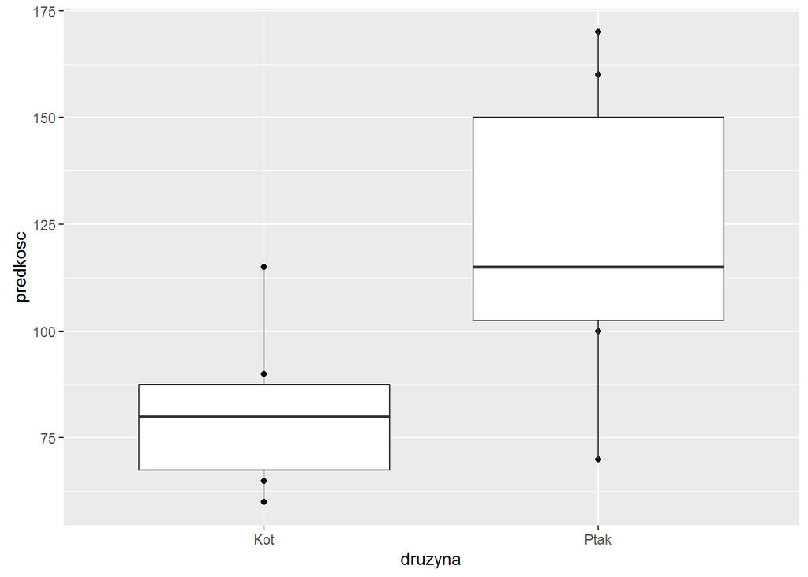

```r
ggplot(koty_ptaki, aes(x = druzyna, y = predkosc)) +
     geom_point() +
     geom_boxplot()
```

Jeśli nas interesuje, które wartości są odstające, to dodajmy tekst:

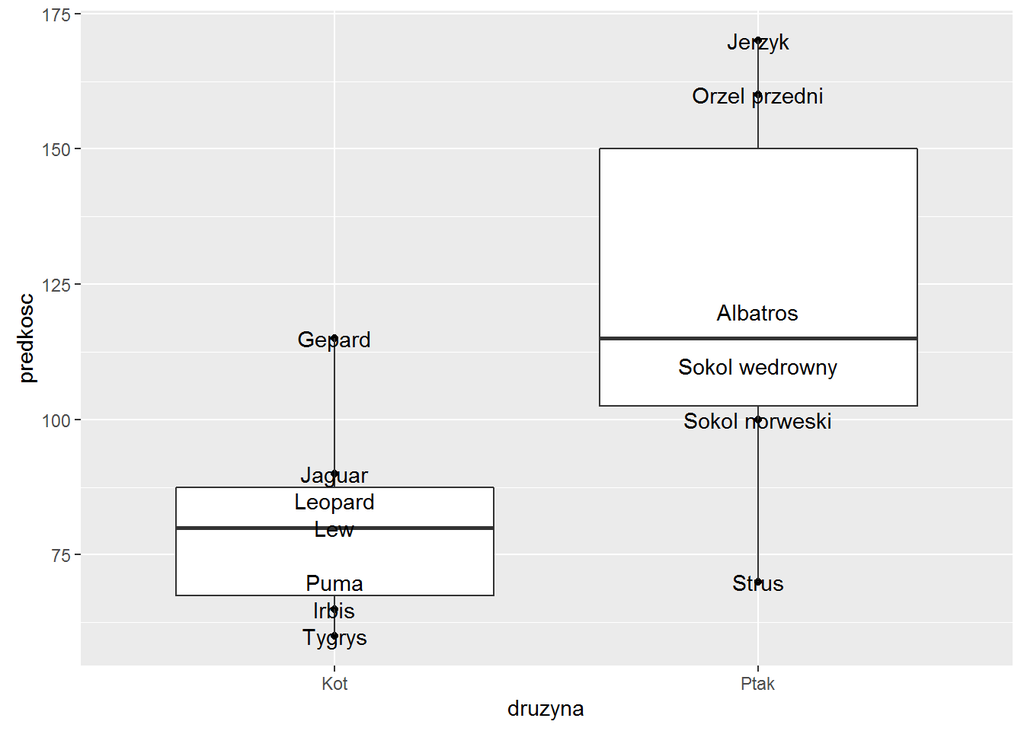

```r
ggplot(koty_ptaki, aes(x = druzyna, y = predkosc, label = gatunek)) +
     geom_point() +
     geom_boxplot() +
     geom_text()
```

## Stylowanie wykresów

Zmiana układu współrzędnych (zamiana osi OX z osią OY):

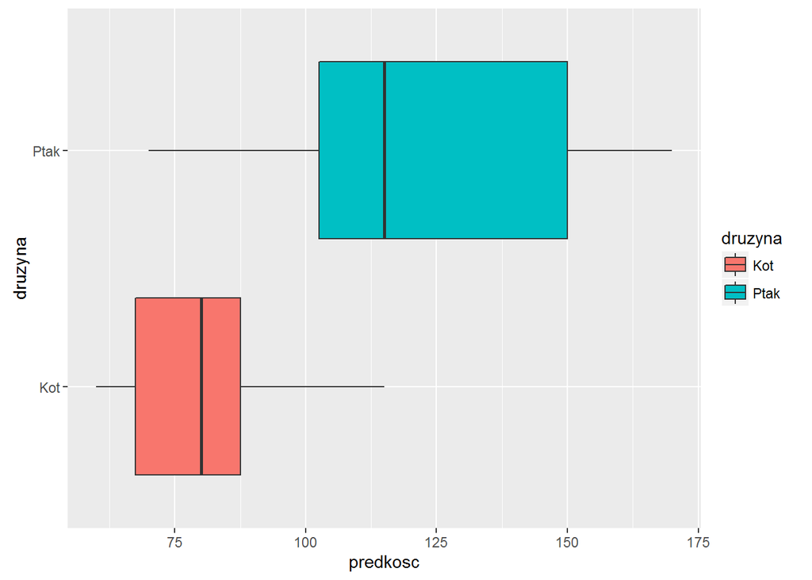

```r
ggplot(koty_ptaki, aes(x = druzyna, y = predkosc, fill = druzyna)) +
     geom_boxplot() +
     coord_flip()
```

Tytuł i nazwy osi:

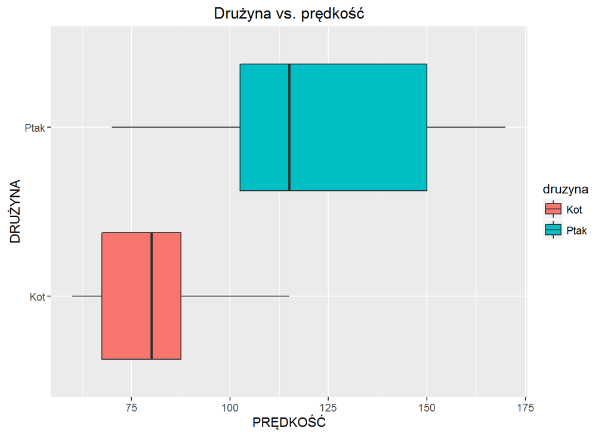

```r
ggplot(koty_ptaki, aes(x = druzyna, y = predkosc, fill = druzyna)) +
     geom_boxplot() +
     coord_flip() +
     labs(title = "Drużyna vs. prędkość", x = "DRUŻYNA", y = "PRĘDKOŚĆ")
```

Motywy (`theme_bw()`, `theme_minimal()`, `theme_classic()`, `theme_gray()`, …):

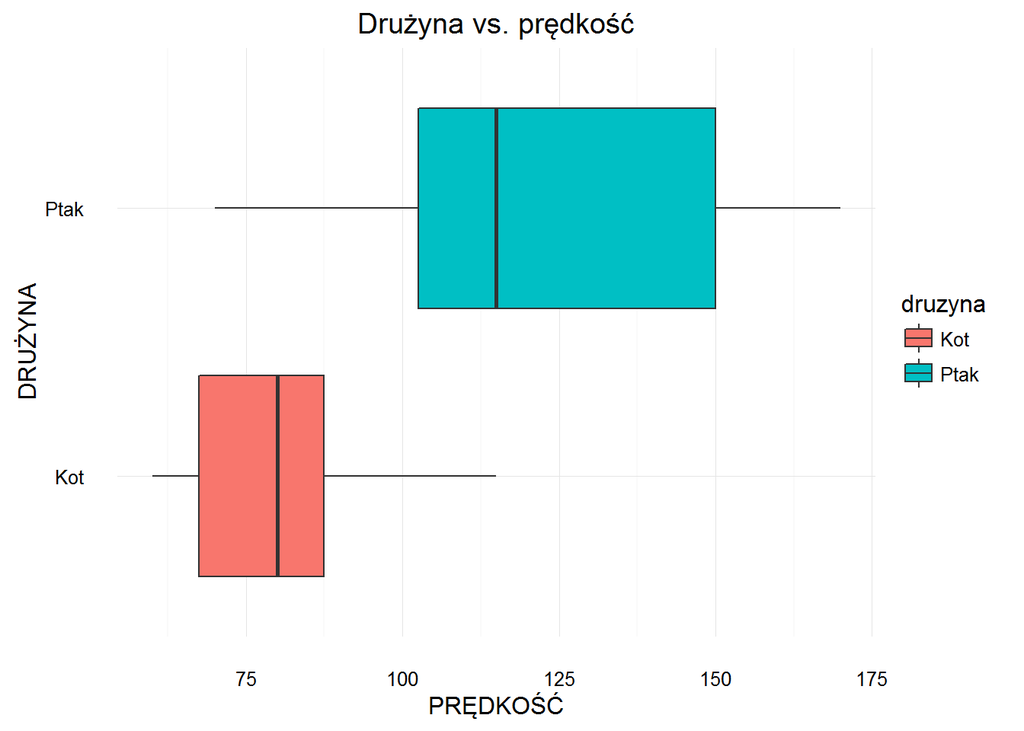

```r
ggplot(koty_ptaki, aes(x = druzyna, y = predkosc, fill = druzyna)) +
     geom_boxplot() +
     coord_flip() +
     labs(title = "Drużyna vs. prędkość", x = "DRUŻYNA", y = "PRĘDKOŚĆ") +
     theme_minimal()
```

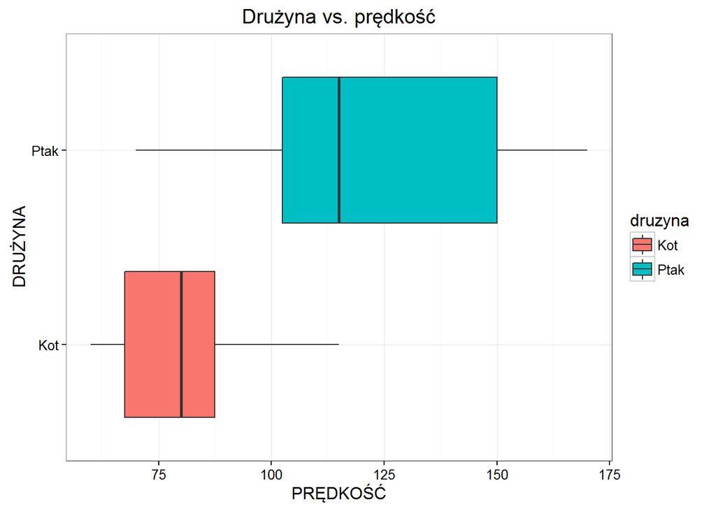

```r
ggplot(koty_ptaki, aes(x = druzyna, y = predkosc, fill = druzyna)) +
     geom_boxplot() +
     coord_flip() +
     labs(title = "Drużyna vs. prędkość", x = "DRUŻYNA", y = "PRĘDKOŚĆ") +
     theme_bw()
```

Stylowanie szczegółów (wielkość tekstu, czcionka, …):

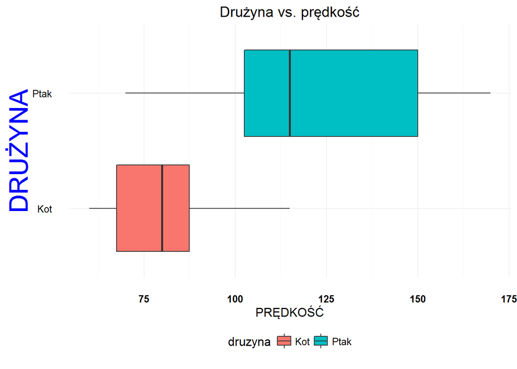

```r
ggplot(koty_ptaki, aes(x = druzyna, y = predkosc, fill = druzyna)) +
     geom_boxplot() +
     coord_flip() +
     labs(title = "Drużyna vs. prędkość", x = "DRUŻYNA", y = "PRĘDKOŚĆ") +
     theme_minimal() +
     theme(axis.title.y = element_text(size = 25, color = "blue"),
           axis.text.x = element_text(face = "bold"),
           legend.position = "bottom")
```

Modyfikacja skali (`scale_color_discrete()`, `scale_fill_manual()`, …):

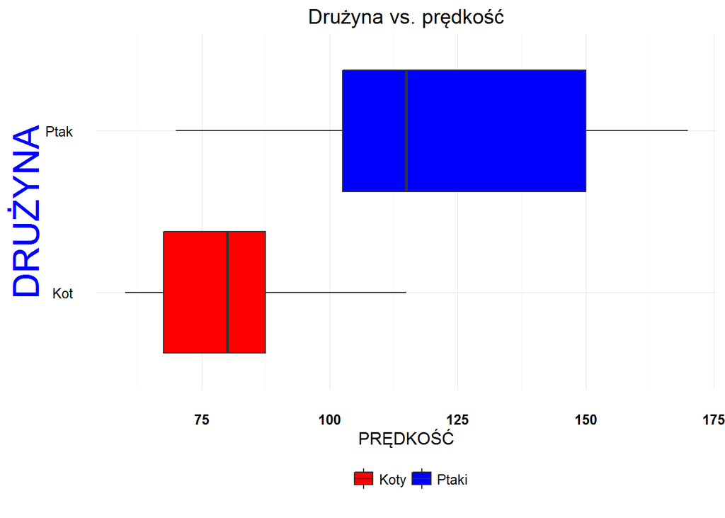

```r
ggplot(koty_ptaki, aes(x = druzyna, y = predkosc, fill = druzyna)) +
     geom_boxplot() +
     coord_flip() +
     labs(title = "Drużyna vs. prędkość", x = "DRUŻYNA", y = "PRĘDKOŚĆ") +
     theme_minimal() +
     theme(axis.title.y = element_text(size = 25, color = "blue"),
           axis.text.x = element_text(face = "bold"),
           legend.position = "bottom") +
     scale_fill_manual(values = c("red", "blue"), labels = c("Koty", "Ptaki"), name = "")
```

## Dane o serialach

```r
data("serialeIMDB")
head(serialeIMDB)
```

```
##   id       serial                         nazwa sezon odcinek ocena glosow
## 1  1 Breaking Bad                         Pilot     1       1   8.7   9357
## 2  2 Breaking Bad           Cat's in the Bag...     1       2   8.2   6506
## 3  3 Breaking Bad ...And the Bag's in the River     1       3   8.3   6176
## 4  4 Breaking Bad                    Cancer Man     1       4   7.9   5796
## 5  5 Breaking Bad                   Gray Matter     1       5   7.9   5664
## 6  6 Breaking Bad      Crazy Handful of Nothin'     1       6   8.7   6521
##      imdbId
## 1 tt0903747
## 2 tt0903747
## 3 tt0903747
## 4 tt0903747
## 5 tt0903747
## 6 tt0903747
```

Wyciągamy tylko dane o ‘Grze o tron’ i rysujemy wykres zależności oceny od sezonu:

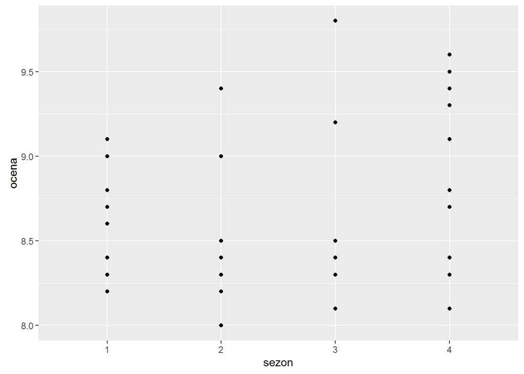

```r
serialeIMDB %>% filter(serial == "Game of Thrones") -> gra_o_tron

ggplot(gra_o_tron, aes(x = sezon, y = ocena)) +
     geom_point()
```

Zamiast punktów możemy narysować wykresy pudełkowe:

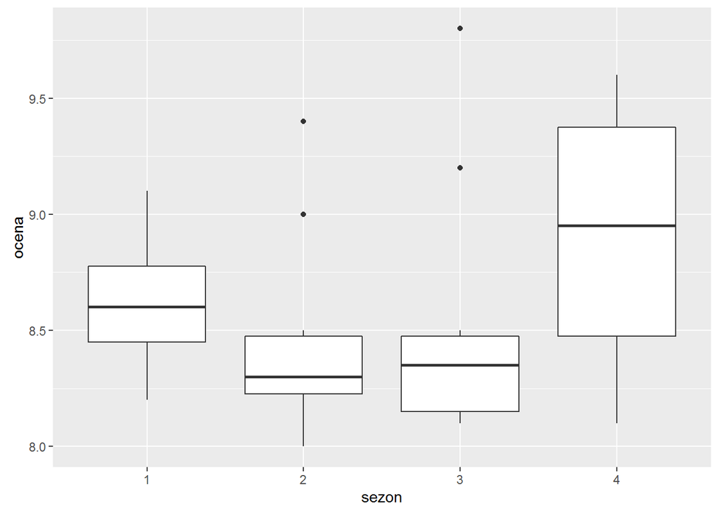

```r
ggplot(gra_o_tron, aes(x = sezon, y = ocena)) +
     geom_boxplot()
```

A teraz wybierzmy więcej seriali i dla nich narysujmy to samo:

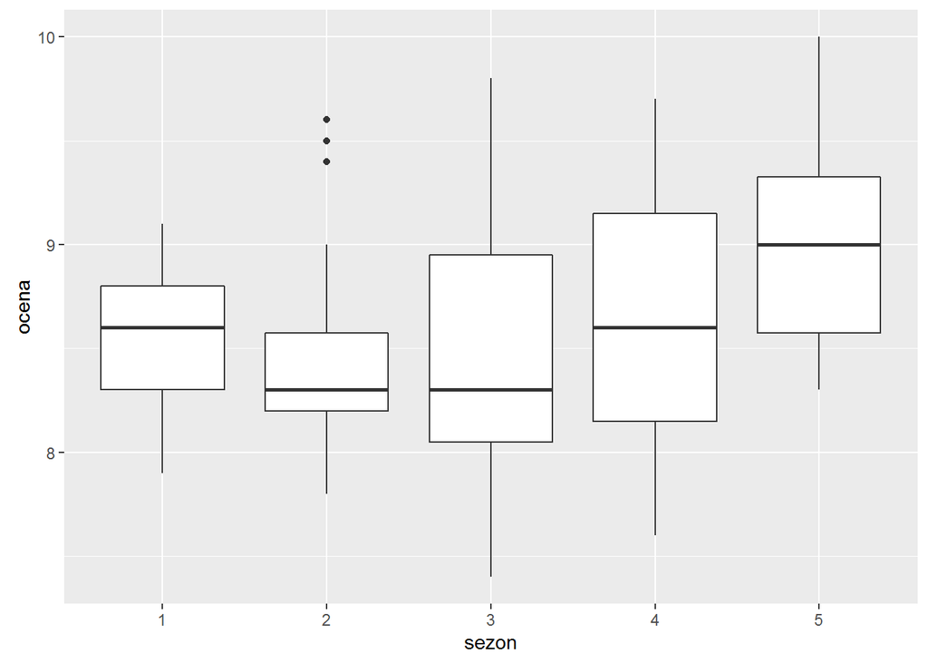

```r
serialeIMDB %>% filter(serial %in% c("Game of Thrones", "Sherlock", "Breaking Bad")) -> seriale

ggplot(seriale, aes(x = sezon, y = ocena)) +
     geom_boxplot()
```

Warto byłoby odróżniać seriale:

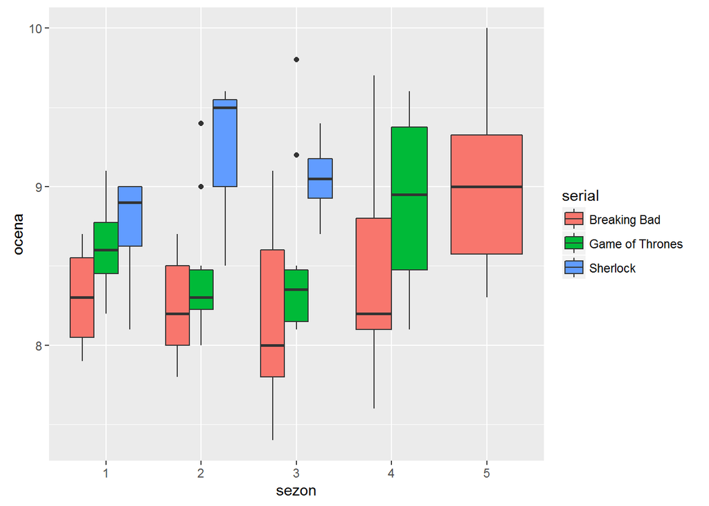

```r
ggplot(seriale, aes(x = sezon, y = ocena, fill = serial)) +
     geom_boxplot()
```

## Panele

Trochę za dużo tego na jednym wykresie. Podzielmy to więc na panele:

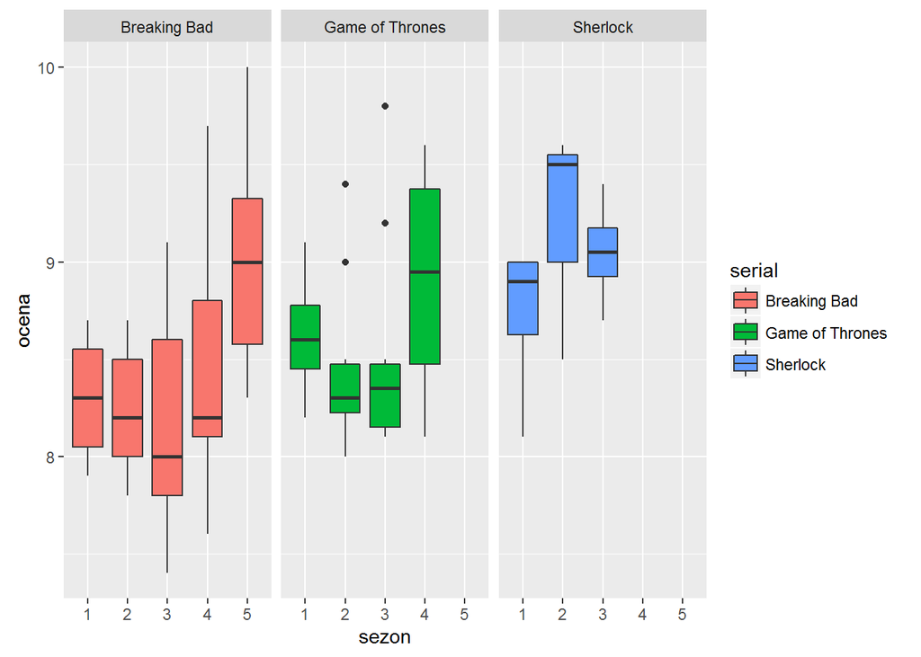

```r
ggplot(seriale, aes(x = sezon, y = ocena, fill = serial)) +
     geom_boxplot() +
     facet_grid( ~ serial)
```

‘Sherlock’ nie ma aż pięciu sezonów, więc ‘uwolnijmy mu skalę’:

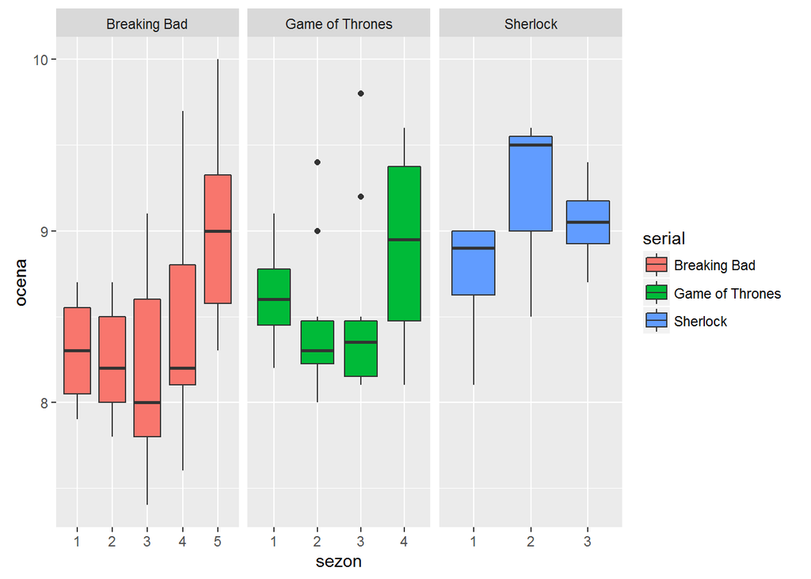

```r
ggplot(seriale, aes(x = sezon, y = ocena, fill = serial)) +
     geom_boxplot() +
     facet_grid(. ~ serial, scales = "free_x")
```

To samo, tylko poziomo:

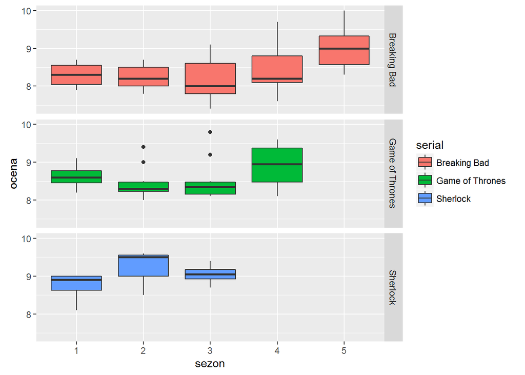

```r
ggplot(seriale, aes(x = sezon, y = ocena, fill = serial)) +
     geom_boxplot() +
     facet_grid(serial ~ ., scales = "free_x")
```

## Wykresy interaktywne

Potrzebny tu jest pakiet `plotly()`.

```r
ggplot(seriale, aes(x = sezon, y = ocena, fill = serial)) +
     geom_boxplot() +
     facet_grid(serial ~ ., scales = "free_x") -> wykres

ggplotly(wykres)
```

[interactive chart not shown]

```r
ggplot(koty_ptaki, aes(x = dlugosc, y = waga, color = druzyna, label = gatunek)) +
     geom_point() +
     geom_text() -> wykres2

ggplotly(wykres2)
```

[interactive chart not shown]

## Zadania

Korzystamy ze zbioru `imiona_warszawa` i `serialeIMDB`:

```r
head(imiona_warszawa)
```

```
##    imie plec  rok miesiac liczba
## 1 Aaron    M 2004       7      0
## 2 Aaron    M 2004       8      0
## 3 Aaron    M 2004       9      0
## 4 Aaron    M 2004      10      0
## 5 Aaron    M 2004      11      0
## 6 Aaron    M 2004      12      0
```

### 1. Narysuj wykres przedstawiający zależność liczby dwojga wybranych dzieci urodzonych od roku.

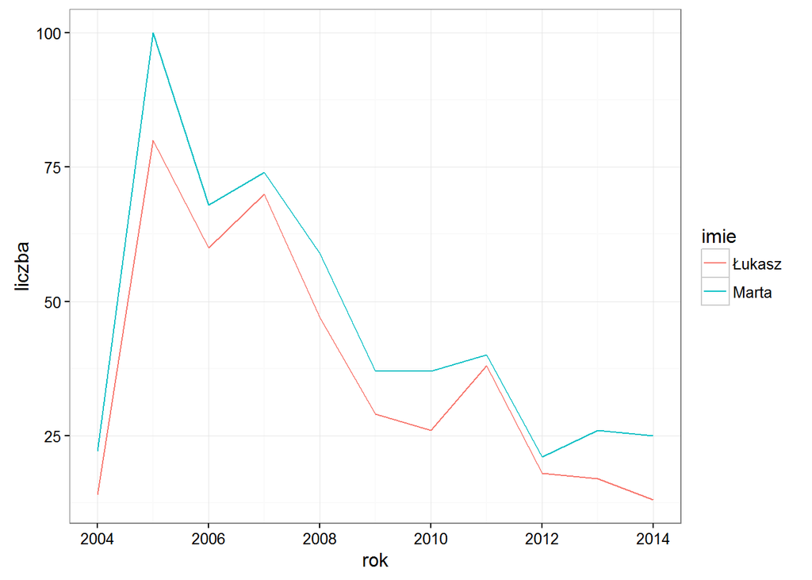

### 2. Przedstaw na wykresie liczbę głosów oddanych na kolejne odcinki wybranego serialu (z dodatkowym wymiarem przedstawionym kolorem - oceną).

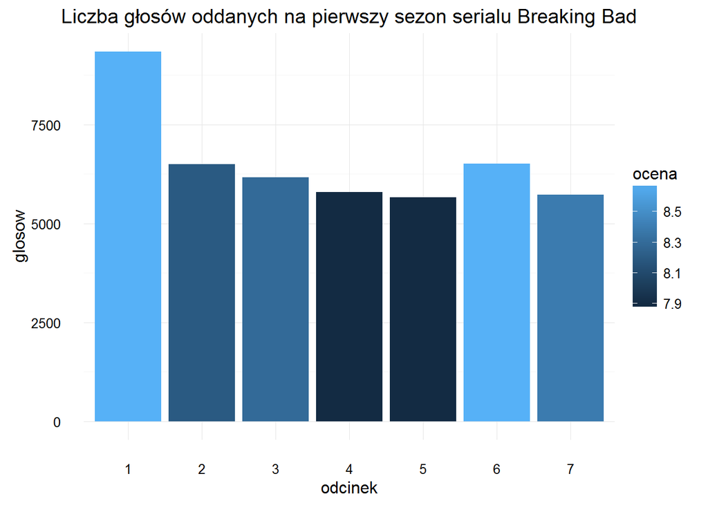

### 3. Przedstaw na wykresie liczbę głosów oddanych na kolejne odcinki wybranych dwóch seriali w zależności od oceny tych odcinków.

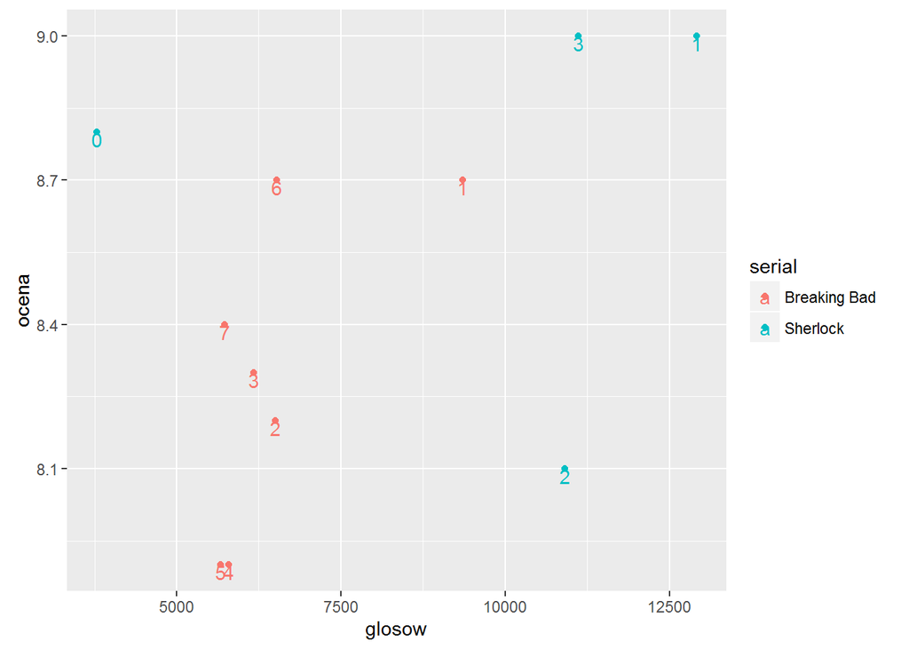